# Data Science Jobs in Australia - EDA

Evan Guo

2021-11-16

# Table of Contents

1. Objective
2. Exploratory Data Analysis
1. Most Common Words in Data Science Job Ads
2. Which programming languages (and tools) are most in-demand for Data Scientist roles in Australia?
3. What kind of salaries are Data Scientists earning in Australia?
4. How many Data Scientist jobs were listed in australia, how did it compare to a year ago (pre COVID in Australia), do salaries differs by geographical area and where are these jobs located?
5. How many Data Science Related Roles offered by companies in Australia?
3. Conclusion
4. References
5. Code

# Objective

**It’s certainly something that seems to be on people’s minds lately.** Everyone is talking about it, a lot are claiming to do it, and increasingly, more people are hiring for it.

**But what is it?**

Data science, in its most basic terms, can be defined as obtaining insights and information, really anything of value, out of data. In reality, data science is evolving so fast and has already shown such enormous range of possibility that a wider definition is essential to understanding it.

So here we’ll do data analysis to answer some interesting questions related to data science that you’ve always wanted to know like-

**How many Data Scientist jobs were listed in australia, how did it compare to a year ago (pre COVID in Australia), and where are these jobs located?**

**Which programming languages (and tools) are most in-demand for Data Scientist roles in Australia?**

**What kind of salaries are Data Scientists earning in Australia, do salaries differ by language and geographic area, and have they changed at all in the past year?**

So, let’s get started. Here, we will use the dataset which comprises every australian data science job listing for a year!

**First Import the required libraries and load the dataset**

**Let’s check the head of the dataset.**

|  | jobId | jobTitle | jobClassification | jobSubClassification | advertiserName |
| --- | --- | --- | --- | --- | --- |
| 1 | 38098375 | Senior Method Development Immunoassay Scientist - Adelaide Location | Science &amp; Technology | Biological &amp; Biomedical Sciences | Hobson Prior Australia |
| 2 | 38259053 | Pricing Data Scientist - Lower North Shore | Information &amp; Communication Technology | Other | Randstad - Technologies |
| 3 | 38267899 | Insights Analyst – Online Video Streaming | Information &amp; Communication Technology | Database Development &amp; Administration | Aurec |
| 4 | 38267995 | Credit Risk Analyst | Banking &amp; Financial Services | Compliance &amp; Risk | Huxley Associates |
| 5 | 38269206 | Data Scientist | Information &amp; Communication Technology | Database Development &amp; Administration | FinXL IT Professional Services |
| 6 | 38269216 | Data Scientist | Information &amp; Communication Technology | Database Development &amp; Administration | FinXL IT Professional Services |
| 7 | 38270740 | Data Scientist | Banking &amp; Financial Services | Analysis &amp; Reporting | Macquarie Group Limited |
| 8 | 38272439 | Data Scientist | Banking &amp; Financial Services | Analysis &amp; Reporting | Bluefin Resources Pty Limited |
| 9 | 38273974 | Senior Data Scientist | Information &amp; Communication Technology | Consultants | Robert Walters |
| 10 | 38274601 | Data Scientist | Science &amp; Technology | Mathematics, Statistics &amp; Information Sciences | Motion Recruitment |

[output cut: 10 more lines]

If you look at the data carefully, you’ll get to know that the state column contains states from UK and other so we will filter the state column first and start our analysis.

**Now Let’ check any missing values in data.**

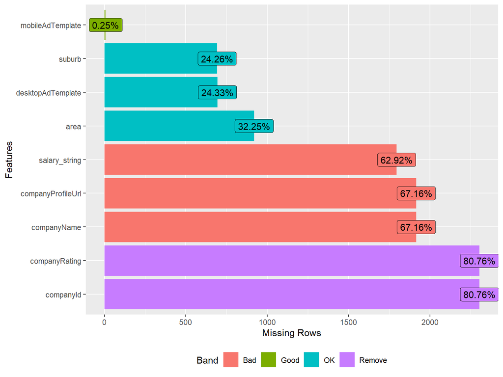

From the above plot, we can see that there are the features which is having missing values.

Go to top:Table of Contents

**We have to clean and preprocess the relavant data to make the analysis more understandable.**

## Exploratory Data Analysis

### Analysis of Job Description

The Job description is one of the most important thing when we think of any kind of job. In this dataset, two fields having the description of jobs: desktopAdTemplate and mobileAdTemplate and we have seen above both the features contains missing values.

One more thing if we look at the data carefully. we will get to know that some words are joined together in mobileAdTemplate so only desktopAdTemplate make sense and we will continue further EDA with that variable only.

Go to top:Table of Contents

## Which programming languages (and tools) are most in-demand for Data Scientist roles in Australia?

As you know if you want to make a career in data science, you need to know the languages which are the most important to learn. so lets check the important tools and languages used by companies in australia.

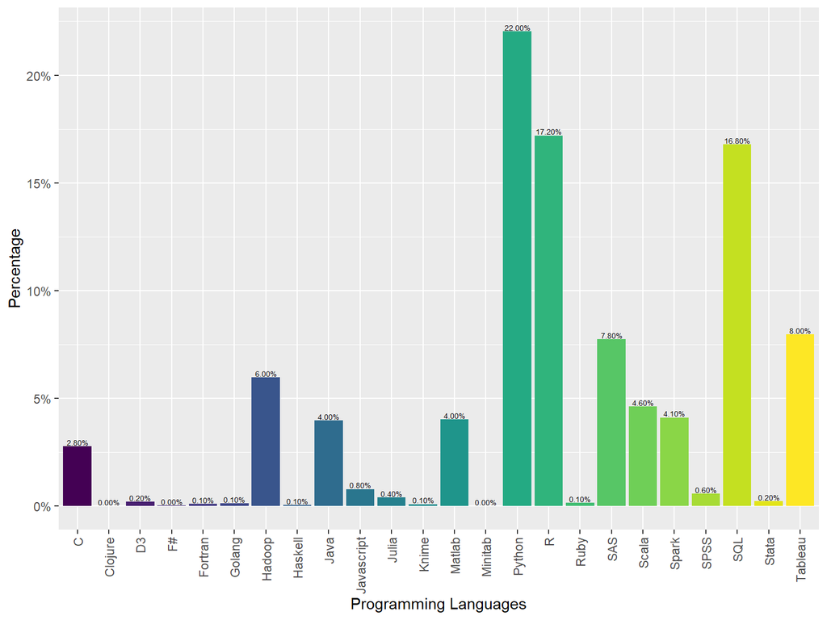

Represented above are the counts of job ads as they appear in the search results for each language/software.

- It is clearly seen from the above that Python, R and SQL are the top 3 programming language used in data science field.
- Hadoop, Scala and Spark are also very popular but in data science field, they are very popular for data engineering purposes.

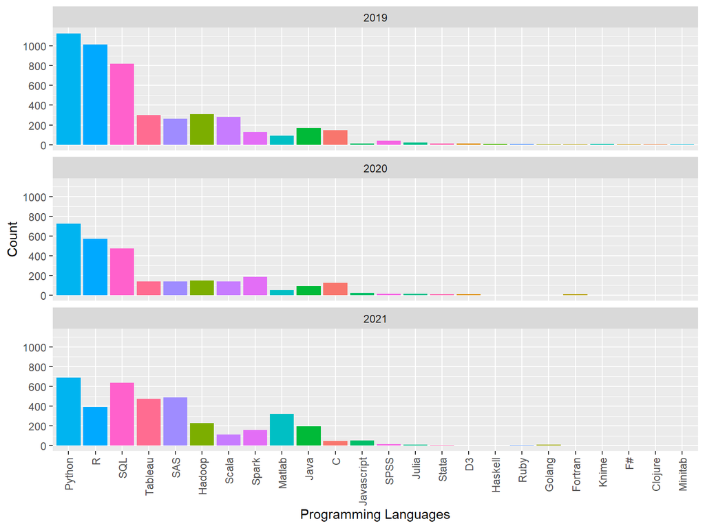

Go to top:Table of Contents

## What kind of salaries are Data Scientists earning in Australia?

According to Google, The average salary for a Data Scientist in Australia is between **AU$75,233 per year- AU$121,578** per year based on one’s experience.

### Salary Distribution by Job Titles

|  | jobTitle | count | avg_salary |
| --- | --- | --- | --- |
| 1 | Data Scientist | 1135 | 142410.15 |
| 2 | Senior Data Scientist | 305 | 150219.53 |
| 3 | Lead Data Scientist | 59 | 179329.33 |
| 4 | Junior Data Scientist | 36 | 96605.26 |
| 5 | Data Engineer | 17 | 125000 |
| 6 | Assistant Directors - Statisticians and Data Professionals | 14 | 109686 |
| 7 | Data Analyst | 14 | 110000 |

Let’s visualize the above table

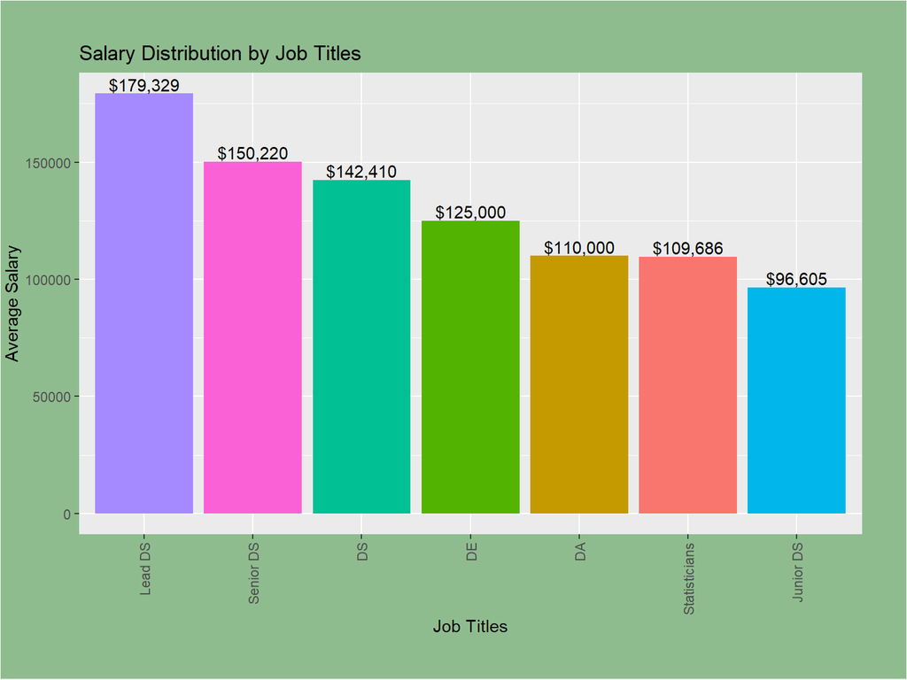

As you can see, the distribution is same as what we expected that is higher salary for Lead and Senior Data Scientist.

### Salary Distribution by Language

|  | factor(languages) | avg_salary | max_salary | min_salary | count |
| --- | --- | --- | --- | --- | --- |
| 1 | C | 142324.57 | 336000 | 70000 | 89 |
| 2 | D3 | 136999.83 | 200000 | 103555 | 12 |
| 3 | Golang | 195944.44 | 300000 | 80000 | 9 |
| 4 | Hadoop | 153013.56 | 331200 | 80000 | 164 |
| 5 | Java | 152296.13 | 336000 | 62500 | 110 |
| 6 | Javascript | 126127.04 | 300000 | 62500 | 25 |
| 7 | Julia | 135000 | 150000 | 125000 | 3 |
| 8 | Knime | 105000 | 105000 | 105000 | 1 |
| 9 | Matlab | 148282.15 | 360000 | 62500 | 118 |
| 10 | Python | 142345 | 360000 | 58000 | 656 |

[output cut: 9 more lines]

- The Average Salary distribution by programming languages in Australia range from **$58,000 - $360,000**, with an **average of $140,510 and median of $130,000**.
- It seems Stata has highest average salary in Australia for data science.

Go to top:Table of Contents

## How many Data Scientist jobs were listed in australia, how did it compare to a year ago (pre COVID in Australia), and where are these jobs located?

### Salary Distribution by State

[interactive chart not shown]

Let’s See Salary Distribution using Boxplot

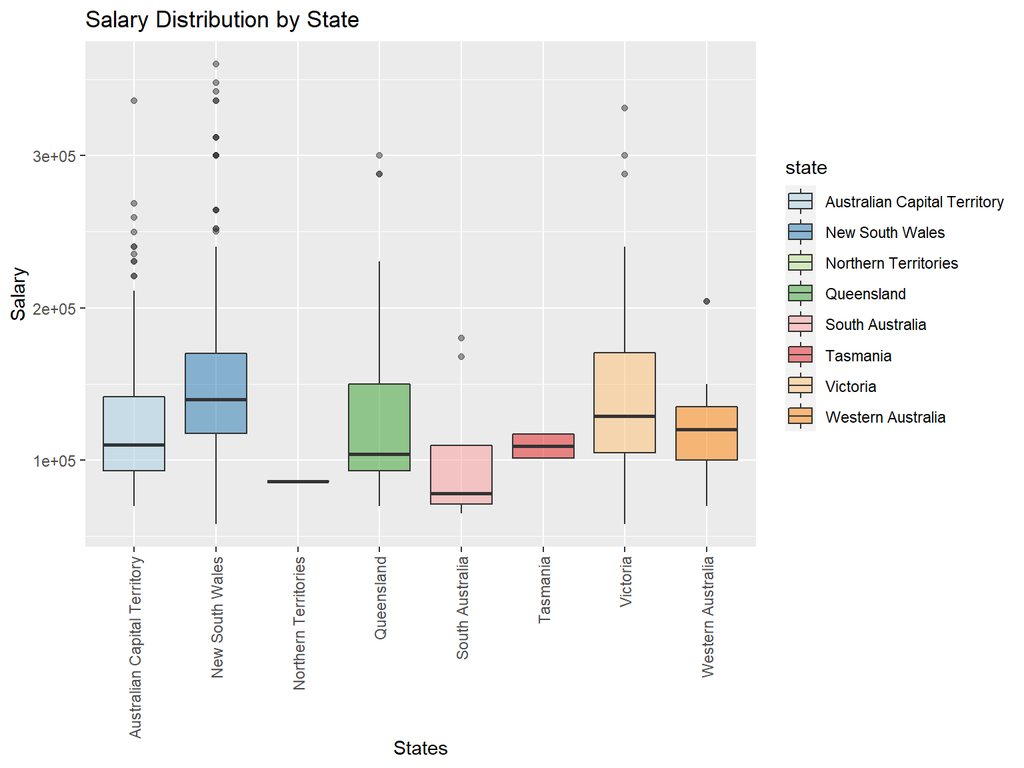

**We can clearly see that geographical area is also plays important role in salaries. different state has different range of salaries.**

### Data Science Job Listings by State

|  | state | count | avg_salary | state_pop | job_listings_per_100k |
| --- | --- | --- | --- | --- | --- |
| 1 | New South Wales | 1239 | 148996.4 | 8176368 | 15.15 |
| 2 | Victoria | 803 | 137702.09 | 6648564 | 12.08 |
| 3 | Queensland | 253 | 125096.62 | 5206400 | 4.86 |
| 4 | Australian Capital Territory | 243 | 133907.47 | 431826 | 56.27 |
| 5 | Western Australia | 204 | 118026.91 | 2675797 | 7.62 |
| 6 | South Australia | 102 | 100317 | 1771703 | 5.76 |
| 7 | Tasmania | 8 | 109260 | 541965 | 1.48 |
| 8 | Northern Territory | 1 | 86025 | 247023 | 0.4 |

**Now this is interesting! ACT, has a massive 56 data scientist job listings per 100k people, more than triple NSW who has ~15 listings per 100k people!**

### Job Listing Posted per Week

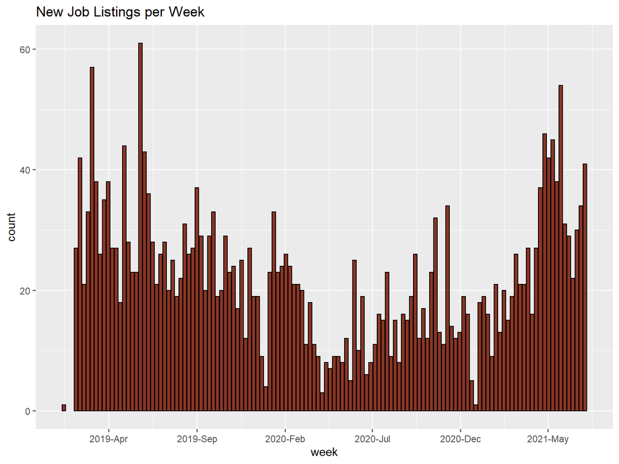

**This is very interesting. We see new listings around April 2020, when Australia experienced COVID-19 outbreaks, and many employers suddenly required employees work from home where possible. In the week starting April 2020, there were only few new Data Scientist job listings in the whole of Australia!**

But Now from April we can see the increament in the number of job postings.

Go to top:Table of Contents

## How many Data Science Related Roles offered by companies in Australia?

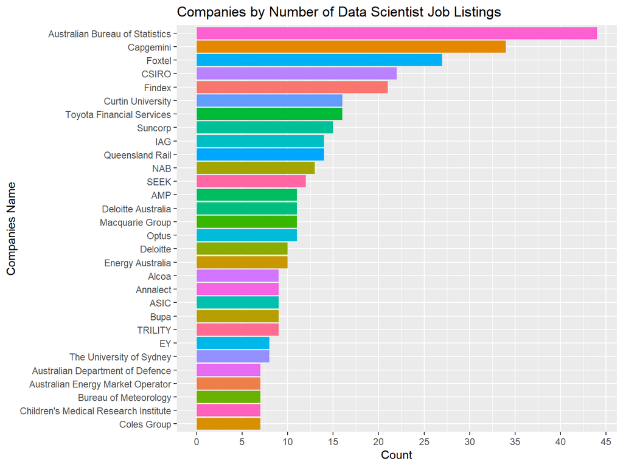

**It looks like ABS, Capgemini, Foxtel, CSIRO are the companies with most number of data science jobs with good rating in Australia.**

Go to top:Table of Contents

# Conclusion

**Now we have lots of interesting points about data science jobs in australia.**

- Python, R and SQL are the most used languages by data scientist in australia.
- Employees with Data Scientist in their job title in New South Wales earns higher than any other state in Australia.
- Australian Capital Territory has a massive 56 data scientist job listings per 100k people, more than triple New South Wales.
- Due to the Covid-19 pandemic and the economic slowdown, many companies went on survival mode, This resulted in a slowdown in the growth of the data science industry in 2020. When there were fewer companies hiring data scientists in the job market and according to our analysis, around first week of April 2020, when Australia experienced COVID-19 outbreaks, there were less than 10 new data scientist job listings in Australia.

# References

[Plotting Anything with ggplot2- Youtube Video](https://www.youtube.com/watch?v=h29g21z0a68)

[Data Visualization- ggplot2](https://r4ds.had.co.nz/data-visualisation.html)

[A Beautiful Plotting in R: A ggplot2 cheatsheet](http://zevross.com/blog/2014/08/04/beautiful-plotting-in-r-a-ggplot2-cheatsheet-3/)

[Intro to ggplot2-Data Visualization with R](https://rkabacoff.github.io/datavis/IntroGGPLOT.html)

[Bivariate Graphs- Data Visualization with R](https://rkabacoff.github.io/datavis/Bivariate.html)

Go to top:Table of Contents

# Code

```r
# Import Libraries
library(readr)
library(rmarkdown)
library(prettydoc)
library(DT)
library(DataExplorer)
library(wesanderson)
library(wordcloud2)
library(dplyr)
library(tidyr)
library(tidytext)
library(lubridate)
library(stringr)
library(ggplot2)
library(scales)
library(viridis)
library(ggtext)
library(priceR)
library(rvest)
library(leaflet)
library(rnaturalearth)
library(rnaturalearthhires)

# Loading Dataset
listings <- read_csv("Datasets/listings2019_2021.csv")

# checking the glimpse of first five rows of data in first page, click next to see the next 5 rows.
datatable(listings[1:20,1:5], options = list(pageLength = 5))

# let's check the structure of dataset to convert the features into correct format.
str(listings)

# lets convert the column first_seen into datetime format.
listings$first_seen <- listings$first_seen %>% as.POSIXct(format="%Y-%m-%d")
# create new feature first_seen_year by extracting only year from the dates.
listings$first_seen_year <- format(listings$first_seen, format="%Y")
# Rename the column 'F.' to 'F#'
colnames(listings)[which(colnames(listings) == "F.")] <- "F#"

listings <- listings %>%
  # Remove Overseas,UK and Ireland data from states
  filter(!state %in% c("Overseas", "UK & Ireland"))

# Let's visualize if any Missing values in data.
# plot_missing(listings,missing_only=TRUE) # uncomment it to use

# creating new column in same dataframe for further analysis
listings <- listings %>%
  mutate(job_description = ifelse(nchar(desktopAdTemplate) == 0, mobileAdTemplate, desktopAdTemplate))

# For text analysis, its better to remove stopwords which contains irrelavant information.
stop_words_except_languages <- stop_words %>%
  # select word only
  select(word) %>%
  # filter words and exclude languages names
  filter(!word %in% c("r", "c", "f", "d", "q")) # These five elements in vector are the name of languages.

# lets split the columns into tokens meaning one token per row
# listing_words <- listings %>%
#   unnest_tokens(word, job_description) %>%
#   anti_join(stop_words_except_languages) %>%
#   distinct()
#
# # lets create wordcloud for top 100 words to get some more words in job ads.
# listing_words %>%
#   count(word, sort = TRUE) %>%
#   head(100) %>%
#   # CODE for wordcloud
#   wordcloud2(size = .2,
#               fontFamily ="serif",
#               shape = 'cloud',
#               ellipticity = 1)

listing_pivot <- listings %>%
  # select jobid and columns from R:fortran using slicing
  select(jobId, R:Fortran,first_seen_year) %>%
  # pivot the selected columns to change the shape of the data
  pivot_longer(cols = R:Fortran, names_to = "languages") %>%
  filter(value == 1) %>%
  mutate(languages = factor(languages))

# lets visualize the data by using barplot
p <- ggplot(listing_pivot,aes(x =languages, fill = languages)) +geom_bar(aes(y = (..count..)/sum(..count..))) +
  geom_text(aes(label = scales::percent(round((..count..)/sum(..count..),3)),y = (..count..)/sum(..count..) ), stat = "count", vjust = -.2,size=1.9) +
  labs(x='Programming Languages',y='Percentage') +
  scale_y_continuous(labels = scales::percent_format(accuracy = 1L)) +
  theme(legend.position = 'none',
        axis.text.x = element_text(hjust = 1,vjust = 0.5,angle=90)) +
  scale_color_viridis(discrete = TRUE , option = "D")+
  scale_fill_viridis(discrete = TRUE)
#p

# Data Science Job Listings in 2020 and 2021.

lang_19_20_21 <- listing_pivot %>%
  # group by using first_seen_year and language- a new feature created using pivot.
  group_by(first_seen_year,languages) %>%
  # count the frequency of languages by each year(2019/2020/2021)
  summarise(count=sum(value))

# creating a year facet
p_19_20_21 <-ggplot(data=lang_19_20_21, aes(x=reorder(languages,-count), y=count,fill = languages)) +
  geom_bar(stat="identity") +
  labs(x='Programming Languages',y='Count') +
  scale_y_continuous(breaks = seq(0,3000,200)) +
  theme(legend.position = 'none',
        axis.text.x = element_text(hjust = 1,vjust = 0.5,angle=90)) +
  facet_wrap(~ first_seen_year,dir = "v")

#p_19_20_21

listings <- listings$salary_string %>%
  extract_salary(
    # Set to minimum Austrlian full time salary that is lower bound
    exclude_below = 740.80  * 48,
    # Set some upper bound
    exclude_above = 600000,
    include_periodicity = TRUE,
     # Since a typical working year in Australia has 48 weeks
    working_weeks_per_year = 48
    ) %>%
  # column bind the listings
  cbind(listings, .)

sal_title <- listings %>%
  # remove the leading white spaces from jobtitle and feed into the same column
  mutate(jobTitle = trimws(jobTitle)) %>%
  # group by job title
  group_by(jobTitle) %>%
  # for each job title count the frequency and calculate the mean of salary by removing null values from it.
  summarise(count=n(),
            avg_salary = round(mean(salary, na.rm = TRUE),2)) %>%
  # filter the NAN values associated with '$' from avg_salary
  filter(avg_salary != "$NaN") %>%
  # arrange the average salary in descending order.
  arrange(desc(count)) %>%
  # create a dataframe
  as.data.frame %>%
  # get the first 7 highest average salaries.
  head(7)

datatable(sal_title, options = list(pageLength = 7))

gg_sal <- ggplot(data = sal_title,aes(x=reorder(jobTitle,-avg_salary), y=avg_salary,fill= jobTitle)) +
  geom_bar(stat="identity") +
  labs(title = "Salary Distribution by Job Titles",x='Job Titles',y='Average Salary') +
  theme(legend.position = 'none',
        axis.text.x = element_text(hjust = 1,vjust = 0.5,angle=90),
        plot.background=element_rect(fill="darkseagreen"),
        plot.margin = unit(c(1, 1, 1, 0.1), "cm")) +
  geom_text(aes(label = dollar(avg_salary)),
            vjust=-0.2) +
  scale_x_discrete(breaks=c("Lead Data Scientist","Senior Data Scientist","Data Scientist",
                              "Data Engineer","Data Analyst","Assistant Directors - Statisticians and Data Professionals","Junior Data Scientist"),
        labels=c("Lead DS", "Senior DS", "DS","DE","DA","Statisticians","Junior DS"))

#gg_sal

### Salary Distribution by Language
salaries_by_lang <- listings %>%
  # select jobid and columns from R:fortran using slicing
  select(salary, R:Fortran) %>%
  # pivot the selected columns to change the shape of the data
  pivot_longer(R:Fortran, names_to = "languages") %>%
  # filter only where language is equal to 1.
  filter(value == 1) %>%
  # select language and salary only for further preprocessing
  select(languages, salary) %>%
  # remove null values from salary
  filter(!is.na(salary)) %>%
  # group by language
  group_by(factor(languages)) %>%
  summarise(avg_salary = round(mean(salary, na.rm = TRUE),2),  # Calculate Average of salary
            max_salary = max(salary,na.rm=TRUE), # Calculate maximum of salary for each language
            min_salary = min(salary,na.rm=TRUE), # Calculate minimum of salary for each language
            count = n())  # frequency count for language

datatable(salaries_by_lang, options = list(pageLength = 10))

### Salary Distribution by State

# Grab the Australian States Information
australian_states <- rnaturalearth::ne_states(country = 'australia')
# Scrape wikipedia Australian states and territories population datasets
australia_pop_page_html <- read_html("https://en.wikipedia.org/wiki/States_and_territories_of_Australia")

# Extract the population page
pop_tables <- australia_pop_page_html %>%
  html_nodes("table")

# Grab data from states table
states <-  pop_tables[[3]] %>%
  html_table %>%
  select(State, 'Population(Mar 2021)[4]') %>%
  rename(state = State, state_pop = 'Population(Mar 2021)[4]')

# Grab data from territories table
territories <-  pop_tables[[4]] %>%
  html_table %>%
  select(Territory, 'Population(Mar 2021)[4]') %>%
  rename(state = Territory, state_pop = 'Population(Mar 2021)[4]')

# Combine the two tables and tidy the data.frame
aus_pop_by_state <- bind_rows(states, territories) %>%
  filter(state != "Jervis Bay Territory") %>%
  mutate(state_pop = state_pop %>% gsub(",", "", .) %>% as.integer)

ds_listings_by_state <- listings %>%
  # group by state
  group_by(state) %>%
  # count the frequency of each state
  summarise(count=n(),   # count the frequency of each state
            avg_salary = round(mean(salary, na.rm = TRUE),2)) %>%  # Remove null values and Calculate Average of salary
  # arrange the frequency count of state in descending order
  arrange(desc(count)) %>%
  # Join the group by data, state and territories data together.
  left_join(aus_pop_by_state) %>%
  # create a new column for job listings per 100K.
  mutate(job_listings_per_100k = round((count/(state_pop/100000)), 2))

ds_state_salaries <- australian_states$name %>%
  data.frame(name = ., stringsAsFactors = FALSE) %>%
  left_join(., ds_listings_by_state, by = c("name"="state")) %>%
  pull(avg_salary)

custom_bins <- c(0, 80, seq(100, 160, 10)) * 1000 # seq(0, 25, 2.5) # c(0, 0.5, 1, 2, 3, seq(4, 8, 2), seq(10, 25, 5))

custom_palette <- colorBin(palette = "Greens",
                           domain = ds_state_salaries,
                           na.color = "transparent",
                           bins = custom_bins)

# Tooltips:
custom_text <- paste(
  "State: ", australian_states$name,"<br/>",
  "Average Salary: ", round(ds_state_salaries, 2),
  sep="") %>%
  lapply(htmltools::HTML)

# Final Map
ds_map <- leaflet(australian_states) %>%
  addTiles(urlTemplate = 'http://{s}.basemaps.cartocdn.com/dark_all/{z}/{x}/{y}.png') %>%
  setView(lat = -29.15, lng = 130.25 , zoom=4) %>%
  addPolygons(
    fillColor = ~custom_palette(ds_state_salaries),
    stroke = TRUE,
    fillOpacity = 0.6,
    color = "white",
    weight = 0.3,
    label = custom_text,
    labelOptions = labelOptions(
      style = list("font-weight" = "normal", padding = "3px 8px"),
      textsize = "13px",
      direction = "auto"
    )
  ) %>%
  addLegend(
    pal = custom_palette,
    values = ~ds_state_salaries,
    opacity=0.9,
    title = "Average DS Salary",
    position = "bottomleft"
  )

ds_map

## Let's See Salary Distribution using Boxplot

ggbox <- ggplot(listings,aes(state,salary,fill=state))+geom_boxplot(alpha=0.5)+
labs(x = "States", y = "Salary")+
scale_fill_manual(values=rainbow(n=8))+
  ggtitle("Salary Distribution by State") + scale_fill_brewer(palette = "Paired") +
  theme(legend.position = "right",
        axis.text.x = element_text(hjust = 1,vjust = 0.5,angle=90))

#ggbox

### Data Science Job Listings by State

datatable(ds_listings_by_state, options = list(pageLength = 10))

### Job Listing Posted per Week
new_jobs_per_week <- listings %>%
  mutate(listingDate = as.Date(listingDate)) %>%
  #Extract week data and apply groupby on it
  group_by(week = floor_date(listingDate, "week")) %>%
  summarise(count=n()) %>%
  ggplot(aes(week, count)) +
  geom_col(fill = "tomato4",color="black") +
  theme(legend.position = "none") +
  labs(title="New Job Listings per Week") +
  scale_x_date(date_labels = "%Y-%b",
               date_breaks = "5 months")

#new_jobs_per_week

comp_jobs <- listings %>%
  # only extracting where employers post a job (Excluding Recruiter)
  filter(recruiter == 0) %>%
  group_by(companyName) %>%
  summarise(count=n(),
            companyRating = mean(companyRating, na.rm=T)) %>%
  arrange(desc(count)) %>%
  filter(companyName != "") %>%
  head(30) %>%
  # Next line ensures the order remains in tact
  mutate(companyName = factor(companyName, levels = rev(unique(companyName)))) %>%
  ggplot(aes(companyName, count)) +
  geom_col(aes(fill = factor(companyRating)))  +
  scale_y_continuous(breaks = seq(0,55,5)) +
  theme(legend.position = "none") +
  scale_color_brewer(palette="Paired") +
  labs(title="Companies by Number of Data Scientist Job Listings",y='Count',x='Companies Name') +
  coord_flip()
#comp_jobs
```